# Języki skryptowe w analizie danych - grafika w `R`

###### dr inż. Marcin Lawnik, mgr inż. Arkadiusz Banasik

### Wytyczne

1. Jedną z metod próbkowania jest metoda odwracania dystrybuanty (np. https://pl.wikipedia.org/wiki/Odwrotna_dystrybuanta). Metoda ta nie nadaję się dla rozkładów, dla których dla dystrybunty nie można określić funkcji odwrotnej. Przykładem takiego rozkładu jest rozkład normalny. Z kolei można przybliżyć dystrybunatę rozkładu $N(0,1)$ poprzez inną funkcję i wtedy zastosować wyżej wspomnianą metodę. Jedną z najprostszych aproksymacji dystrybuanty rozkładu $N(0,1)$ jest funkcja: $$ \Phi_{a} (x) = \frac{e^{2kx}}{1+e^{2kx}}, $$ gdzie $k = \sqrt{\frac{2}{\pi}}$.

   **Zadanie**

   Za pomocą wspomnianej metody i aproksymacji uzyskaj $10^5$ próbek z rozkładu $N(0,1)$ i porównaj je z próbkami uzyskanaymi za pomocą funkcji `rnorm` języka R.

   W tym celu należy:
   1. Znaleźć funkcję odwrotną do $\Phi_{a}$
   2. Uzyskać próbkę z rozkładu $U(0,1)$ (rozkład jednostajny na przedziale (0,1)) za pomocą funkcji `runif` języka R
   3. Podziałać na uzyskanej próbce funkcją odwrotną
   4. Pokazać histogram dla wyniku z kroku 3 i funkcji `rnorm`
2. Stwórz grafikę, której wynikiem jest aproksymacja wartości $\pi$. Aproksymację taką można uzyskać za pomocą metody Monte Carlo (np. https://pl.wikipedia.org/wiki/Metoda_Monte_Carlo).

   W tym celu:
   1. wylosuj $10^4$ wartości pseudolosowych $x$ i $y$, dla których:
   - jeśli należą do koła jednostkowego, tj. spełniają warunek $x^2+y^2 \le 1$, to umiesć wartości $x$ i $y$ w odpowiednich wektorach `wx` i `wy`
   - jesli nie należą do koła jednostkowego, to umieść je w wektorach `px` i `py`
   1. otrzymane pary wektorów `wx` i `wy` oraz `px` i `py` wyplotuj aby uzyskać grafikę

[figure not shown]

   *Wskazówki*
   1. Wartość `a` do pustego wektora `x = c()` można dodać w następujący sposób: `x[length(x)+1] = a`.
   2. Funkcja może zwrócić wiele wyrażeń jeśli umieścimy je w liście. Dla przykładu jeśli chcemy zwrócić 2 wektory `x` i `y`, to możemy stworzyć listę `wynik = list("x" = w, "y" = y)` i ją zwrócić poprzez `return(wynik)`. Odwołanie do wyników poza funkcją może wyglądać następująco:

      ```
      wynik = funkcja()
      x = wynik$x
      y = wynik$y
      ```

**Uwaga**

Na Platformę Zdalnej Edukacji należy wysłać rozwiązanie co najmniej 1. zadania w postaci *ipynb* i *html*.

# Zadanie 2

78551

78551

21449

21449

```
[1] 3.662222
```

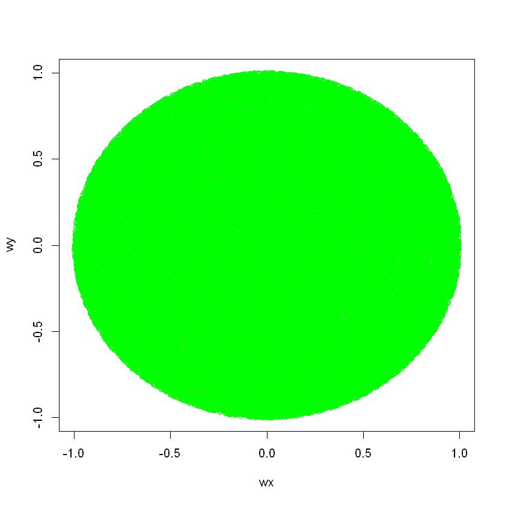

```r
x = runif(10^5, min=-1, max=1)
y = runif(10^5, min=-1, max=1)
wx = c()
wy = c()
px = c()
py = c()
df = data.frame(x=x, y=y)
for(row in 1:nrow(df)){
    if(df[row, "x"]^2 + df[row, "y"]^2 <= 1){
        wx = append(wx, df[row, "x"])
        wy = append(wy, df[row, "y"])
    }
    else{
        px = append(px, df[row, "x"])
        py = append(py, df[row, "y"])
    }
}
length(wx)
length(wy)
length(px)
length(py)

plot(wx, wy, col="green")
print(length(wx) / length(px))
```